# Analise de Polaridade

Diego de Lima

16 de abril de 2019

# Carregando pacotes

```r
library(kableExtra)
library(twitteR)
library(RSQLite)
library(stringr)
library(plyr)
library(ggplot2)
library(tm)
library(RColorBrewer)
library(wordcloud)
library(dplyr)
library(tidyr)
library(slam)
library(sentiment)
library(gridExtra)
source("utils.R")
```

## Carregamento de tweets do Banco de Dados SQLite

Para garantir que os resultados sejam reproduzidos, os tweets foram salvos em banco de dados SQLite para serem carregados e trabalhados posteriormente.

```r
con <- dbConnect(SQLite(), "tweets.db")
tweets_sten <- dbReadTable(con, "sten")
tweets_sten <- tweets_sten$tweets_sten
tweets_fold <- dbReadTable(con, "fold")
tweets_fold <- tweets_fold$tweets_fold
dbDisconnect(con)
```

## Definição do objetivo

Para definir o objetivo, será realizada a avaliação da polaridade do Galaxy S10. Em seguida será realizada a avaliação do Galaxy Fold e comparadas as diferenças de desempenho de ambos.  
Posteriormente será sugerido o objetivo a ser conquistado com as sugestões que serão aparesentadas.

## Limpando tweets e removendo valores Missing

```r
# Galaxy S10
tweets_sten_analysis <- limpaTweets(tweets_sten)
tweets_sten_analysis <- tweets_sten_analysis[!is.na(tweets_sten_analysis)]
names(tweets_sten_analysis) <- NULL
```

## Avaliação de polaridade

```r
# Galaxy S10
class_polar_sten <- classify_polarity(tweets_sten_analysis, algorithm = "bayes")
polaridade_sten <- class_polar_sten[, 4]

# Data set com polaridades
resultados_sten <- data.frame(
  texto = tweets_sten_analysis,
  polaridade = polaridade_sten,
  stringsAsFactors = FALSE
)
```

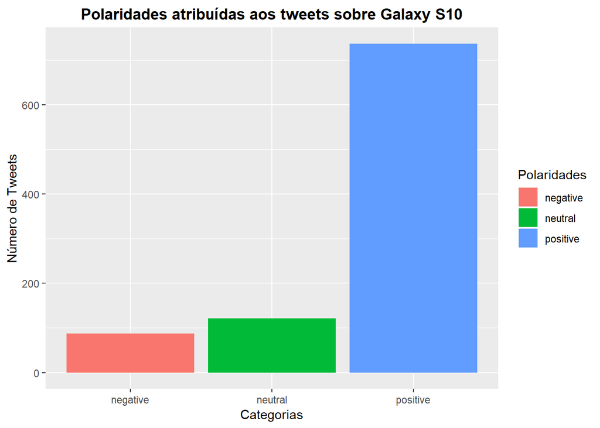

```r
plot_pol_sten <- ggplot(resultados_sten, aes(x = polaridade)) +
  geom_bar(aes(y = ..count.., fill = polaridade)) +
  scale_fill_brewer(palette = "RdGy") +
  scale_fill_discrete(name = "Polaridades") +
  labs(x = "Categorias", y = "Número de Tweets") +
  ggtitle("Polaridades atribuídas aos tweets sobre Galaxy S10") +
  theme(plot.title = element_text(vjust = 0.5, hjust = 0.5, face="bold"))

plot_pol_sten
```

**Na análise de polaridade, foi possível verificar que os tweets referentes ao Galaxy S10 apresentaram maior positividade.**

```r
kable(data.frame(table(resultados_sten$polaridade)) %>%
        mutate(
          Config = round((Freq / sum(Freq))*100, 2)
          )) %>%
  kable_styling(bootstrap_options = c('striped', 'hover', 'condensed'),
                font_size = 9)
```

| Var1 | Freq | Config |
| --- | --- | --- |
| negative | 87 | 9.21 |
| neutral | 121 | 12.80 |
| positive | 737 | 77.99 |

**A configuração da polaridade do Galaxy S10 é:**  
**NEGATIVIDADE:** 9,21%  
**NEUTRALIDADE:** 12,80%  
**POSITIVIDADE:** 77,99%  
**Portanto, esta configuração está sendo assumida como parâmetro para uma boa polaridade do Galaxy Fold.**

```r
# Galaxy Fold
tweets_fold_analysis <- limpaTweets(tweets_fold)
tweets_fold_analysis <- tweets_fold_analysis[!is.na(tweets_fold_analysis)]
names(tweets_fold_analysis) <- NULL
```

## Avaliação de polaridade do Galaxy Fold

```r
class_polar_fold <- classify_polarity(tweets_fold_analysis, algorithm = "bayes")
polaridade_fold <- class_polar_fold[, 4]
```

## Data set com polaridades

```r
resultados_fold <- data.frame(
  texto = tweets_fold_analysis,
  polaridade = polaridade_fold,
  stringsAsFactors = FALSE
)
```

## Apresentação dos resultados de polaridade do Galaxy Fold

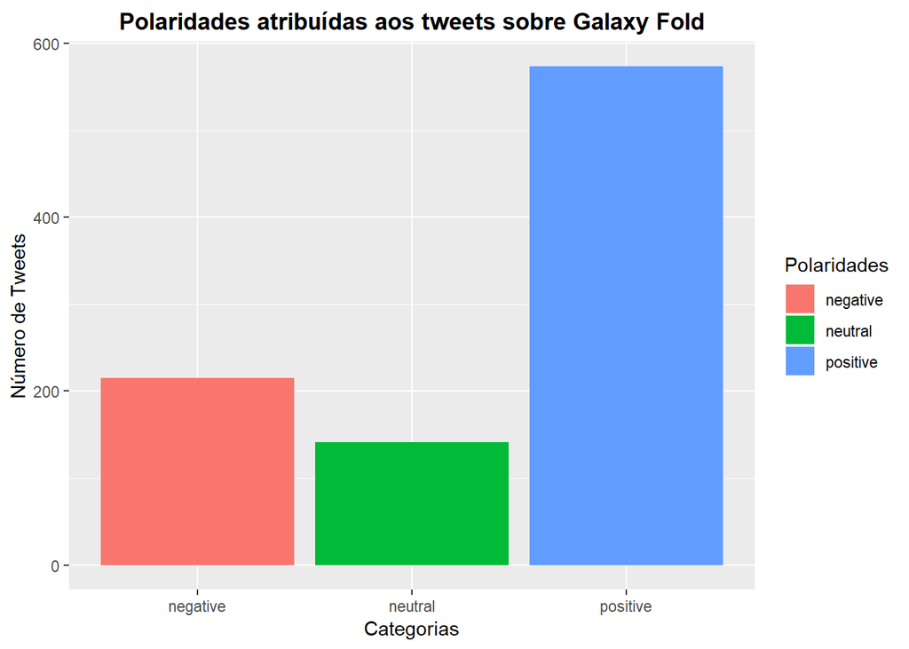

```r
plot_pol_fold <- ggplot(resultados_fold, aes(x = polaridade)) +
  geom_bar(aes(y = ..count.., fill = polaridade)) +
  scale_fill_brewer(palette = "RdGy") +
  scale_fill_discrete(name = "Polaridades") +
  labs(x = "Categorias", y = "Número de Tweets") +
  ggtitle("Polaridades atribuídas aos tweets sobre Galaxy Fold") +
  theme(plot.title = element_text(vjust = 0.5, hjust = 0.5, face="bold"))

plot_pol_fold
```

**Embora a polaridade resultante do Galaxy Fold possua uma predominância positiva, a sua configuração se difere negativamente em relação ao Galaxy S10.**

```r
kable(data.frame(table(resultados_fold$polaridade)) %>%
        mutate(
          Config = round((Freq / sum(Freq))*100, 2))) %>%
  kable_styling(bootstrap_options = c('striped', 'hover', 'condensed'),
                font_size = 9)
```

| Var1 | Freq | Config |
| --- | --- | --- |
| negative | 215 | 23.12 |
| neutral | 141 | 15.16 |
| positive | 574 | 61.72 |

**A configuração da polaridade do Galaxy Fold é:**  
**NEGATIVIDADE:** 23,12%  
**NEUTRALIDADE:** 15,16%  
**POSITIVIDADE:** 61,72%

**Portanto, foi identificado um oportunidade de melhoria reduzindo a negatividade do Galaxy Fold de forma que todas ações sugeridas devam possuir um potencial de melhoria que se aproxime a polaridade do Galaxy Fold ao do Galaxy S10.**

## Análise de Score

Como ponto de partida para identificar possíveis pontos estratégicos a serem abordados para de forma à sugerir ações de melhoria, serão avaliadas as palavras utilizadas nos tweets, e classificadas entre boas ou ruins. Ao final será calculado o score de cada produto.  
Um conjunto de palavras positivas e negativas serão utilizados para avaliar o score de cada produto em relação ao uso de palavras nos tweets.

```r
pos = readLines("palavras_positivas.txt")
neg = readLines("palavras_negativas.txt")
```

## Criando função para calcular scores

Os scores serão calculados com base nas palavras utilizadas nos tweets onde, para cada palavra negativa será atribuído 1 ponto para negatividade, e para cada palavra positiva será atribuído 1 ponto para positividade.  
O cálculo final do score será dado pelo total de pontos positivos subtraído dos pontos negativos.  
Sendo assim scores com resultado 0 representa um equilibrio o que sugere neutralidade no uso das palavras.

```r
calcula_score = function(tweets, pos.words, neg.words){
  # Criando um array de scores
  scores = laply(tweets,
                 function(tweet, pos.words, neg.words)
                 {
                   # Removendo pontuações, caracteres especiais e dígitos
                   tweet = gsub("[[:punct:]]", "", tweet)
                   tweet = gsub("[[:cntrl:]]", "", tweet)
                   tweet = gsub('\\d+', '', tweet)
                   # Formatando os textos para lowercase
                   tweet = sapply(tweet, tolower)
                   # Criando lista de palavras separando por espaço
                   word.list = str_split(tweet, "\\s+")
                   words = unlist(word.list)

                   # Verificando se as palavras estão na lista positiva e negativa
                   pos.matches = match(words, pos.words)
                   neg.matches = match(words, neg.words)
                   # Removendo valores missing
                   pos.matches = !is.na(pos.matches)
                   neg.matches = !is.na(neg.matches)
                   # Calculando e retornando o score do texto
                   # Sempre que houver mais ocorrências negativas, o score será negativo
                   # Sempre que houver mais ocorrências positivas, o score será positivo
                   # Caso o score for 0, o texto não contém palavras positivas ou negativas
                   # contidas nas listas
                   score = sum(pos.matches) - sum(neg.matches)
                   return(score)
                 }, pos.words, neg.words)
  # Criando data frame contendo o texto e seu score
  scores.df = data.frame(text = tweets, score = scores)
  return(scores.df)
}
# Vetor contendo o número de tweets coletados de cada dispositivo
num_tweets = c(length(tweets_sten), length(tweets_fold))
# Vetor contendo todos os tweets de cada dispositivo
tweets = c(tweets_sten, tweets_fold)
```

Calculando score de sentimento

```r
scores = calcula_score(tweets, pos, neg)
# Atribui o dispositivo para os scores
scores$text = factor(rep(c("Galaxy S10", "Galaxy Fold"), num_tweets))
# Inclui campos positivo enegativo para contagem de quantas ocorrências há de cada dispositivo
scores$positivo = as.numeric(scores$score >= 1)
scores$negativo = as.numeric(scores$score <= -1)
# Calcula o score final de cada dispositivo
scores_finais <- data.frame(Dispositivo = c("Galaxy S10", "Galaxy Fold"),
                            Score = c(
                              sum(scores[scores$text == "Galaxy S10", "positivo"]) - sum(scores[scores$text == "Galaxy S10", "negativo"]),
                              sum(scores[scores$text == "Galaxy Fold", "positivo"]) - sum(scores[scores$text == "Galaxy Fold", "negativo"])
                            ))
```

Plotando gráfico contendo score final de cada dispositivo

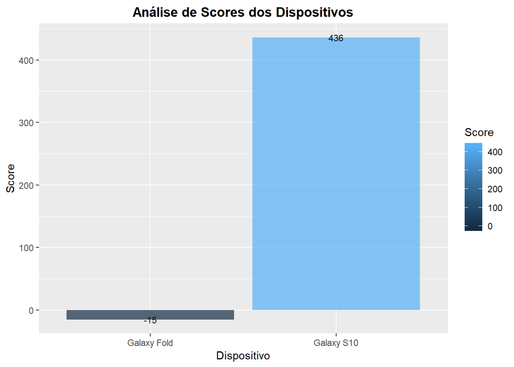

```r
ggplot(scores_finais, aes(x = Dispositivo, y = Score)) +
  geom_col(aes(fill = Score), alpha = 0.7) +
  ggtitle("Análise de Scores dos Dispositivos") +
  geom_text(aes(label = Score), size = 3) +
  theme(plot.title = element_text(vjust = 0.5, hjust = 0.5, face="bold"))
```

**Conforme pode ser analisado no gráfico, o Galaxy S10 teve um score positivo. Porém o Galaxy Fold possuiu um score inferior.**  
Considerando o tamanho da amostra de 1000 tweets um score de -15 pode ser interpretado como equilibrado ao invés de se assumir como negativo.

## Verificando a distribuição de scores por tweet

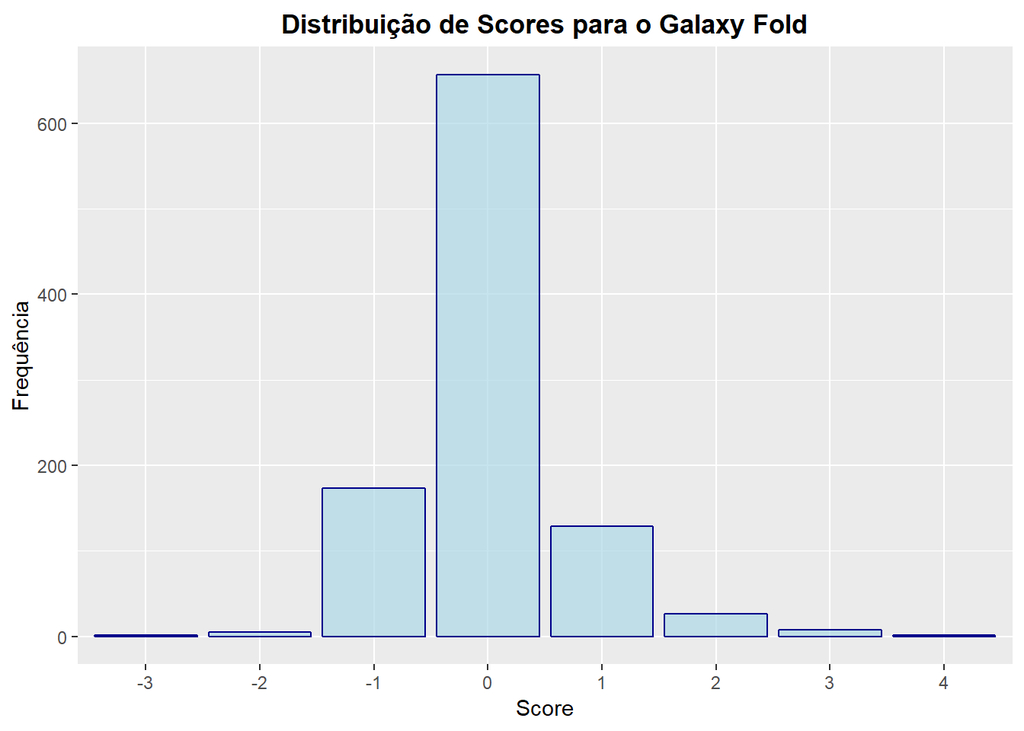

```r
scores_fold <- data.frame(table(scores[scores$text == "Galaxy Fold", "score"]))
ggplot(scores_fold, aes(x = Var1, y = Freq)) +
  geom_col(fill = 'lightblue', color = "darkblue", alpha = 0.7) +
  ggtitle("Distribuição de Scores para o Galaxy Fold") +
  xlab("Score") +
  ylab("Frequência") +
  theme(plot.title = element_text(vjust = 0.5, hjust = 0.5, face = "bold"))
```

**Conforme gráfico acima, a distribuição mostra que de fato houve uma predominância de neutralidade, ao invés da negatividade.**  
**Porém, neutro ou negativo, são potenciais situações para serem convertidas à positividade, resultando assim em melhoria.**

É importante esclarecer também que, o score negativo não representa uma expectativa negativa do público, como já foi evidenciado com a polaridade.  
Neste projeto o score sugere que houve um maior número de palavras negativas referente ao produto do que positivas, e compreender estas palavras é extremamente importante para identificar pontos específicos a serem melhorados.

Para se certificar novamente de que o score negativo não está representando expectativa negativa ao produto, foram realizadas rápidas pesquisas na web, e foi possível notar destaques positivos em relação ao Galaxy Fold, no que diz respeito à critica especializada. Isto considerando o dia 16/04/19 aproximadamente às 16 horas.  
- https://www.tecmundo.com.br/dispositivos-moveis/140452-galaxy-fold-nao-decepciona-vem-gerando-primeiras-impressoes-positivas.htm  
- https://9to5google.com/2019/04/16/samsung-galaxy-fold-impressions-roundup/  
- https://www.extremetech.com/mobile/289550-first-impressions-of-the-galaxy-fold-are-cautiously-optimistic  
- https://www.technobuffalo.com/samsung-galaxy-fold-review

Esta diferença existente entre o positivismo da critica especializada e o score negativo, pode se dar por diferentes fatores, como por exemplo:  
- Poucos tiveram acesso ao dispositivo para análise e primeiras impressões;  
- Dos poucos que tiveram acesso, muitos fazem parte da critica especializada e muitos outros são influenciadores e supostamente patrocinados, podendo resultar em parcialidade;  
- Consumidores em geral podem estar sendo negativos em relação a alguma característica específica do dispositivo.

**Este último será explorado na tentavida de identificar quais características podem estar sob suspeita do público.**

Para compreender melhor estes tweets, vamos analisar as palavras mais utilizadas.

## Limpeza dos tweets

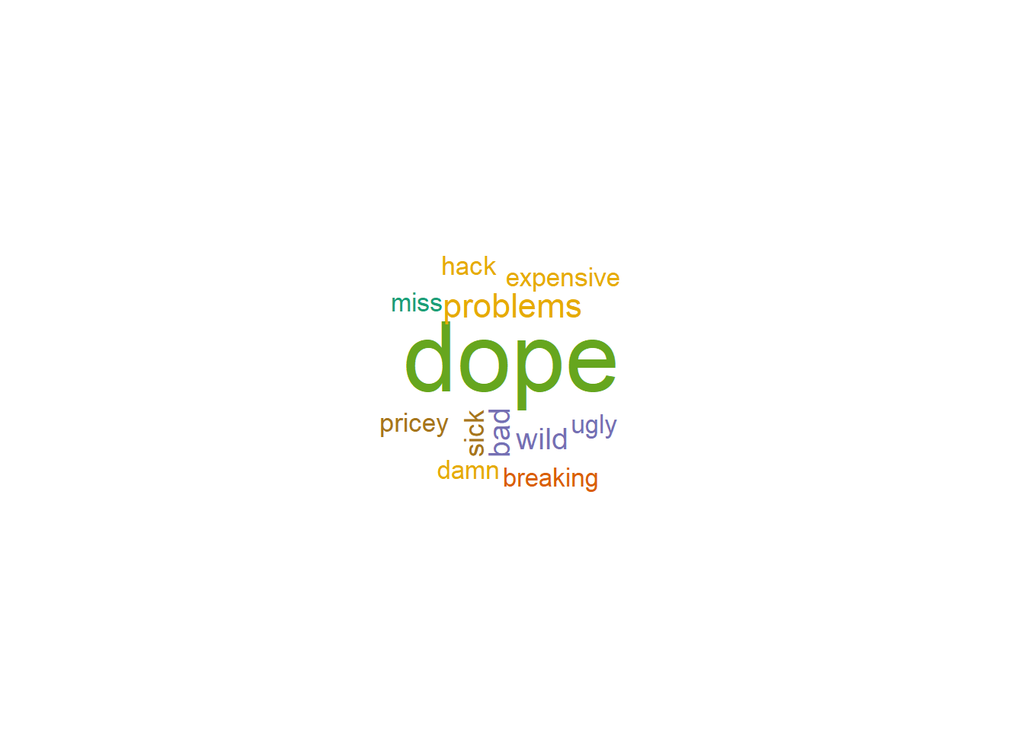

```r
# Remoção de símbolos, números e palavras positivas para se dar foco no conteúdo negativo presente nas mensagens
tweet_fold_clean <- limpaTweets(tweets_fold)
tweet_fold_clean <- Corpus(VectorSource(tweet_fold_clean))
tweet_fold_clean <- tm_map(tweet_fold_clean, removePunctuation)
tweet_fold_clean <- tm_map(tweet_fold_clean, content_transformer(tolower))
tweet_fold_clean <- tm_map(tweet_fold_clean, function(x) removeWords(x, stopwords()))
tweet_fold_clean <- tm_map(tweet_fold_clean, function(x) removeWords(x, pos))

# Agrupamento do conjunto de palavras em Matrix
tweet_matrix <- TermDocumentMatrix(tweet_fold_clean)

# Data set contendo a frequência de cada palavra
freq <- data.frame(rowSums(as.matrix(tweet_matrix)))
freq <- data.frame(rownames(freq), freq)
rownames(freq) <- NULL
colnames(freq) <- c("WORD", "FREQ")

# Verificando as palavras negativas de maior número de ocorrência
wordcloud(words = freq[freq$WORD %in% neg & freq$FREQ > 1, "WORD"],
          freq = freq[freq$WORD %in% neg & freq$FREQ > 1, "FREQ"],
          max.words = 100,
          scale = c(4, 1),
          random.color = TRUE,
          random.order = FALSE,
          colors = brewer.pal(8, "Dark2"))
```

Com um grande destaque para a palavra “dope”, vamos verificar a diferença de frequência entre as demais palavras, para planejar uma análise contextual do uso destas palavras.

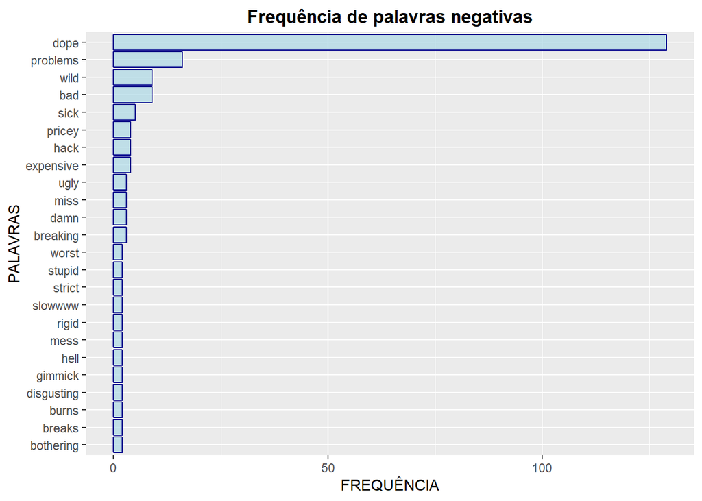

```r
ggplot(freq[freq$WORD %in% neg & freq$FREQ > 1,], aes(x = reorder(WORD, FREQ), y = FREQ)) +
  geom_col(fill = "lightblue", color = "darkblue", alpha=0.7) +
  coord_flip() +
  xlab("PALAVRAS") +
  ylab("FREQUÊNCIA") +
  ggtitle("Frequência de palavras negativas") +
  theme(plot.title = element_text(vjust = 0.5, hjust = 0.5, face = "bold"))
```

Com uma presença muito superior das demais, a palavra “dope” deve ser estrategicamente analisada em contexto, identificando possíveis receios ou críticas a serem cobertas pela SAMSUNG.

```r
kable(grep("dope", tweets_fold, value = TRUE)) %>%
  kable_styling(bootstrap_options = c('striped', 'hover', 'condensed'),
                font_size = 9)
```

| x |
| --- |
| RT @MKBHD: A Galaxy Fold with an S-Pen would’ve been dope. |
| RT @MKBHD: A Galaxy Fold with an S-Pen would’ve been dope. |
| RT @MKBHD: A Galaxy Fold with an S-Pen would’ve been dope. |
| RT @MKBHD: A Galaxy Fold with an S-Pen would’ve been dope. |
| RT @MKBHD: A Galaxy Fold with an S-Pen would’ve been dope. |
| RT @MKBHD: A Galaxy Fold with an S-Pen would’ve been dope. |
| RT @MKBHD: A Galaxy Fold with an S-Pen would’ve been dope. |
| RT @MKBHD: A Galaxy Fold with an S-Pen would’ve been dope. |
| RT @MKBHD: A Galaxy Fold with an S-Pen would’ve been dope. |
| RT @MKBHD: A Galaxy Fold with an S-Pen would’ve been dope. |
| RT @MKBHD: A Galaxy Fold with an S-Pen would’ve been dope. |
| RT @MKBHD: A Galaxy Fold with an S-Pen would’ve been dope. |
| RT @MKBHD: A Galaxy Fold with an S-Pen would’ve been dope. |
| RT @MKBHD: A Galaxy Fold with an S-Pen would’ve been dope. |
| RT @MKBHD: A Galaxy Fold with an S-Pen would’ve been dope. |
| RT @MKBHD: A Galaxy Fold with an S-Pen would’ve been dope. |
| RT @MKBHD: A Galaxy Fold with an S-Pen would’ve been dope. |
| RT @MKBHD: A Galaxy Fold with an S-Pen would’ve been dope. |
| RT @MKBHD: A Galaxy Fold with an S-Pen would’ve been dope. |
| RT @MKBHD: A Galaxy Fold with an S-Pen would’ve been dope. |
| RT @MKBHD: A Galaxy Fold with an S-Pen would’ve been dope. |
| RT @MKBHD: A Galaxy Fold with an S-Pen would’ve been dope. |
| RT @MKBHD: A Galaxy Fold with an S-Pen would’ve been dope. |
| RT @MKBHD: A Galaxy Fold with an S-Pen would’ve been dope. |
| RT @MKBHD: A Galaxy Fold with an S-Pen would’ve been dope. |
| RT @MKBHD: A Galaxy Fold with an S-Pen would’ve been dope. |
| RT @MKBHD: A Galaxy Fold with an S-Pen would’ve been dope. |
| RT @MKBHD: A Galaxy Fold with an S-Pen would’ve been dope. |
| RT @MKBHD: A Galaxy Fold with an S-Pen would’ve been dope. |
| Galaxy fold is pretty dope and It’s premium my dream product |

[output cut: 99 more lines]

## Análise

Em grande maioria o texto negativa um possível uso da S-PEN no dispositivo. Em uma breve consulta nas discussões do tweeter procurando pela mesma expressão, pode-se verificar que de fato há uma grande expectativa negativa quanto ao uso da S-Pen sobre a tela dobrável, de forma que esta venha a possivelmente a apresentar riscos devido o material de plástico.  
Embora não confirmada para este aparelho, a S-Pen é um anseio aparente dos usuários, uma vez que possibilitaria explorar melhor o uso da tela maior.

Neste ponto sugere-se que cobrindo este assunto em futuras apresentações, demonstrando testes e explicando melhor sobre o possível uso da S-PEN, pode-se obter um resultando mais positivo eliminando esta especulação.  
**O potencial resultado com esta ação será calculado removendo os tweets que contenham esta palavra.**

## Calculando Score sem tweets com a palavra “dope”

```r
# Vetor contendo o número de tweets coletados de cada dispositivo
num_tweets2 = c(length(tweets_fold), length(tweets_fold[-grep("dope", tweets_fold)]))
# Vetor contendo todos os tweets de cada dispositivo
tweets2 = c(tweets_fold, tweets_fold[-grep("dope", tweets_fold)])
```

Calculando score de sentimento

```r
scores2 = calcula_score(tweets2, pos, neg)
# Atribui o dispositivo para os scores
scores2$text = factor(rep(c("Before", "After"), num_tweets2))
# Inclui campos positivo enegativo para contagem de quantas ocorr?ncias h? de cada dispositivo
scores2$positivo = as.numeric(scores2$score >= 1)
scores2$negativo = as.numeric(scores2$score <= -1)
# Calcula o score final de cada dispositivo
scores_finais2 <- data.frame(Versao = c("Before", "After"),
                             Score = c(
                               sum(scores2[scores2$text == "Before", "positivo"]) - sum(scores2[scores2$text == "Before", "negativo"]),
                               sum(scores2[scores2$text == "After", "positivo"]) - sum(scores2[scores2$text == "After", "negativo"])
                             ))
```

Plotando gráfico contendo score final de cada dispositivo

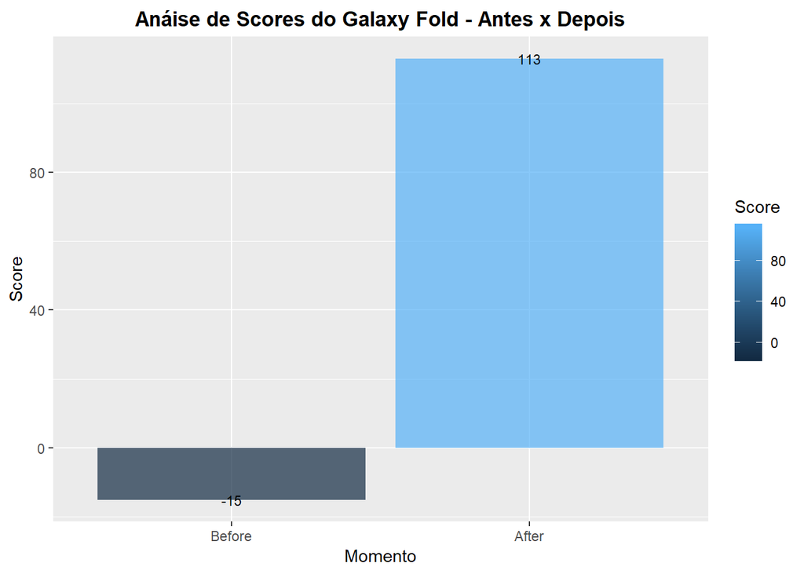

```r
ggplot(scores_finais2, aes(x = reorder(Versao, Score), y = Score)) +
  geom_col(aes(fill = Score), alpha = 0.7) +
  ggtitle("Anáise de Scores do Galaxy Fold - Antes x Depois") +
  geom_text(aes(label = Score), size = 3) +
  xlab("Momento") +
  theme(plot.title = element_text(vjust = 0.5, hjust = 0.5, face="bold"))
```

**Conforme esperado o score saltaria de -15 para 113, sendo o total de 128 pontos o potencial de ganho dentro desta mesma amostragem.**

## Classificação de polaridade sem os tweets que contenham a palavra “dope”.

```r
class_polar_fold_after <- classify_polarity(tweets_fold_analysis[-grep("dope", tweets_fold_analysis)], algorithm = "bayes")
polaridade_fold_after <- class_polar_fold_after[, 4]

resultados_fold_after <- data.frame(
  texto = tweets_fold_analysis[-grep("dope", tweets_fold_analysis)],
  polaridade = polaridade_fold_after,
  stringsAsFactors = FALSE
)
```

Apresentação dos resultados de polaridade do Galaxy Fold

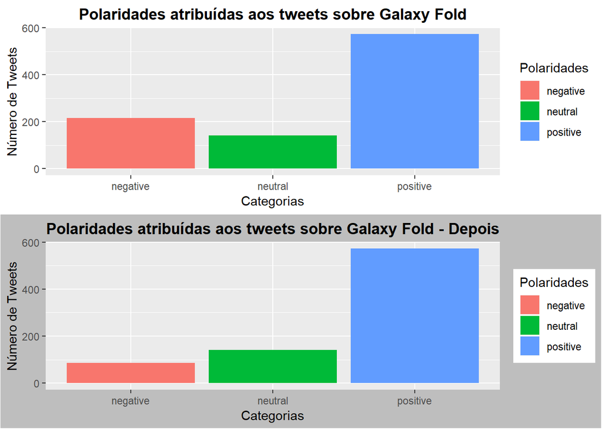

```r
plot_pol_fold_after <- ggplot(resultados_fold_after, aes(x = polaridade)) +
  geom_bar(aes(y = ..count.., fill = polaridade)) +
  scale_fill_brewer(palette = "RdGy") +
  scale_fill_discrete(name = "Polaridades") +
  labs(x = "Categorias", y = "Número de Tweets") +
  ggtitle("Polaridades atribuídas aos tweets sobre Galaxy Fold - Depois") +
  theme(plot.title = element_text(vjust = 0.5, hjust = 0.5, face="bold"),
        plot.background = element_rect(fill = "gray"))

grid.arrange(plot_pol_fold, plot_pol_fold_after, nrow = 2)
```

**Conforme evidenciado houve uma redução da expectativa negativa com a remoção dos tweets com a palavra “dope”.**

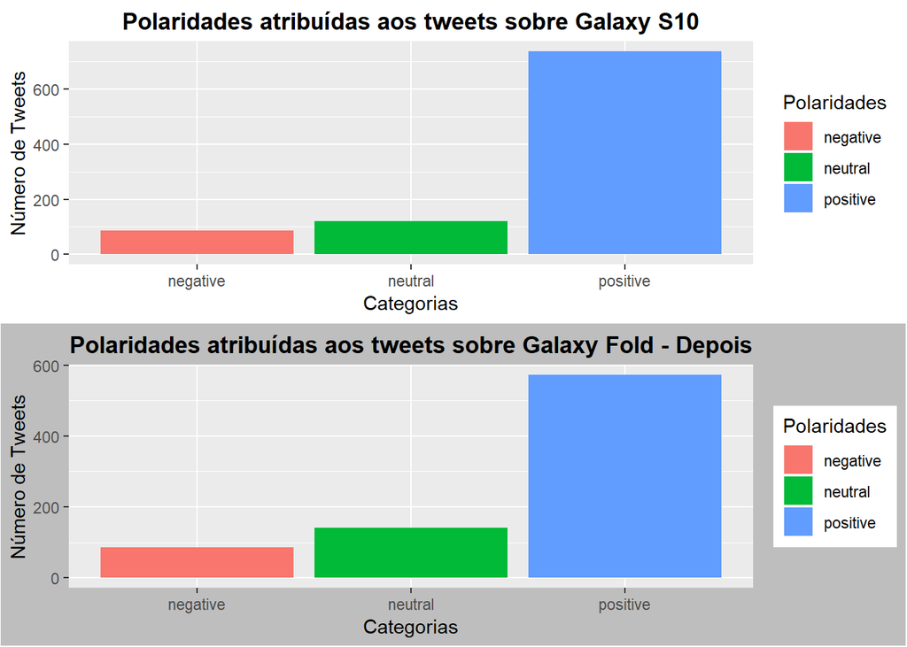

```r
grid.arrange(plot_pol_sten, plot_pol_fold_after, nrow = 2)
```

**Com este avanço a configuração de polaridade ficou com o mesmo padrão obtido para o Galaxy S10, conforme esperado.**

```r
kable(data.frame(table(resultados_fold_after$polaridade)) %>%
  mutate(
    Config = round((Freq / sum(Freq))*100, 2)
  )) %>%
  kable_styling(bootstrap_options = c('striped', 'hover', 'condensed'),
                font_size = 9)
```

| Var1 | Freq | Config |
| --- | --- | --- |
| negative | 87 | 10.86 |
| neutral | 141 | 17.60 |
| positive | 573 | 71.54 |

**A nova configuração possui os seguintes avanços**  
**NEGATIVIDADE:** 10,86% = redução de 12,26%  
**NEUTRALIDADE:** 17,60% = aumento de 2,44%  
**POSITIVIDADE:** 71,54% = aumento de 9,82%

**Estes avanços evidenciam um potencial positivo em relação ao objetivo estabelecido.**

A segunda palavra com maior frequência é “problems”, que embora possa ser genérica, sua contextualização é importante para identificar possíveis padrões a serem estrategicamente explorados.

```r
kable(grep("problems", tweets_fold, value = TRUE)) %>%
  kable_styling(bootstrap_options = c('striped', 'hover', 'condensed'),
                font_size = 9)
```

| x |
| --- |
| 5 problems that could keep the Galaxy Fold from true success https://t.co/xUa0Dyqqyp |
| 5 problems that could keep the Galaxy Fold from true success https://t.co/VJ1jgTV45H |
| 5 problems that will keep the Galaxy Fold from true success https://t.co/EWzbaR9Iuu https://t.co/Qoq2ekAUpB |
| 5 problems that will keep the Galaxy Fold from true success https://t.co/8etnqvqe2I |
| 5 problems that will keep the Galaxy Fold from true success https://t.co/zlSsSIbr49 |
| Android News: “5 problems that will keep the Galaxy Fold from true success” https://t.co/z79JWa9LZl |
| 5 problems that will keep the Galaxy Fold from true success https://t.co/Tk8iidZEbP #Android https://t.co/tug4N52zsj |
| The Galaxy Fold is a downright unique and futuristic phone, but andrewmartonik points out 5 problems that could kee… https://t.co/oodno3YsI3 |
| 5 problems that will keep the Galaxy Fold from true success https://t.co/QuyKJTMVA3 https://t.co/iJwxyN0iJy |
| RT @androidcentral: The Galaxy Fold is a downright unique and futuristic phone, but @andrewmartonik points out 5 problems that could keep i… |
| 5 problems that will keep the Galaxy Fold from true success https://t.co/exrEfqtswP |
| The Galaxy Fold is a downright unique and futuristic phone, but andrewmartonik points out 5 problems that could kee… https://t.co/eQwN9WPKHF |
| 5 problems that will keep the Galaxy Fold from true success https://t.co/kI28r6tJ4m @slideme https://t.co/oH9HkWV1xa |
| 5 problems that will keep the Galaxy Fold from true success https://t.co/wFEaTJ6PjP https://t.co/vPeTnKf0V0 |
| RT @androidcentral: The Galaxy Fold is a downright unique and futuristic phone, but @andrewmartonik points out 5 problems that could keep i… |
| The Galaxy Fold is a downright unique and futuristic phone, but @andrewmartonik points out 5 problems that could ke… https://t.co/6MwXw4sl9C |

## Análise

Conforme verificado todos os tweets fazem referência a um post que ressalta 5 problemas referente ao Galaxy Fold: https://t.co/xUa0Dyqqyp  
Os problemas levantados são:  
- Qualidade da tela de plástico quanto ao desgaste com possível estresse do material com os movimentos de abre e fecha;  
- Espessura e peso elevados;  
- Pouca compatibilidade de aplicativos;  
- Falta de uma tela meio termo: entre a opção muito pequena quando fechado e a opãoo grande quando aberto;  
- Preço elevado.  
**Todas estas questões são naturais ao lançamento de um conceito. e provenientes da formação dos 4 Ps do Marketing, não dando muita abertura para sugestões pré lançamento. Porém, são questões que a Samsung deve considerar estratégicas para garantir a aceitação e prolongar o tempo de vida deste produto.**

## Contextualizando a palavra “Wild”

```r
kable(grep("wild", tweets_fold, value = TRUE)) %>%
  kable_styling(bootstrap_options = c('striped', 'hover', 'condensed'),
                font_size = 9)
```

| x |
| --- |
| RT @hayatohuseman: The Galaxy Fold is wild. https://t.co/YvF4voChBX |
| RT @hayatohuseman: The Galaxy Fold is wild. https://t.co/YvF4voChBX |
| RT @hayatohuseman: The Galaxy Fold is wild. https://t.co/YvF4voChBX |
| RT @hayatohuseman: The Galaxy Fold is wild. https://t.co/YvF4voChBX |
| Samsung Galaxy Fold: Hands-on with Samsung’s wild foldable phone https://t.co/lgXCnTiyKt |
| RT @hayatohuseman: The Galaxy Fold is wild. https://t.co/YvF4voChBX |
| RT @hayatohuseman: The Galaxy Fold is wild. https://t.co/YvF4voChBX |
| RT @hayatohuseman: The Galaxy Fold is wild. https://t.co/YvF4voChBX |
| Galaxy Fold: Using Samsung’s new foldable phone is a wild ride so far - CNET https://t.co/cNMmGVge5e |

## Análise

Conforme veirificado os tweets se referem a um tweet que questiona o fato do aparelho fechar facilmente com uma mão, mas não ser possível de abrir sem utlizar a segunda mão, podendo dificultar o manuseio com fechamentos acidentais: https://t.co/YvF4voChBX  
Se tratando de um tweet de um usuário que está com um modelo para teste, uma resposta da empresa deve antecipar o lançamento oficial e portanto ser abordado em pré lançaamento.  
**Novamente, o potencial resultado com esta ação será calculado removendo os tweets que possuam esta palavra.**

## Calculando Score sem tweets com as palavras “dope” e “wild”

```r
# Vetor contendo o número de tweets coletados de cada dispositivo
num_tweets2 = c(length(tweets_fold), length(tweets_fold[-grep("dope|wild", tweets_fold)]))
# Vetor contendo todos os tweets de cada dispositivo
tweets2 = c(tweets_fold, tweets_fold[-grep("dope|wild", tweets_fold)])

# Calculando score de sentimento
scores2 = calcula_score(tweets2, pos, neg)
# Atribui o dispositivo para os scores
scores2$text = factor(rep(c("Before", "After"), num_tweets2))
# Inclui campos positivo enegativo para contagem de quantas ocorr?ncias h? de cada dispositivo
scores2$positivo = as.numeric(scores2$score >= 1)
scores2$negativo = as.numeric(scores2$score <= -1)
# Calcula o score final de cada dispositivo
scores_finais2 <- data.frame(Versao = c("Before", "After"),
                             Score = c(
                               sum(scores2[scores2$text == "Before", "positivo"]) - sum(scores2[scores2$text == "Before", "negativo"]),
                               sum(scores2[scores2$text == "After", "positivo"]) - sum(scores2[scores2$text == "After", "negativo"])
                             ))
```

Plotando gráfico contendo score final de cada dispositivo

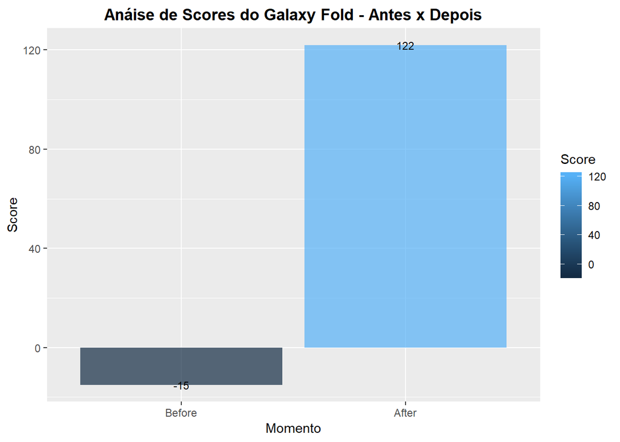

```r
ggplot(scores_finais2, aes(x = reorder(Versao, Score), y = Score)) +
  geom_col(aes(fill = Score), alpha = 0.7) +
  ggtitle("Anáise de Scores do Galaxy Fold - Antes x Depois") +
  geom_text(aes(label = Score), size = 3) +
  xlab("Momento") +
  theme(plot.title = element_text(vjust = 0.5, hjust = 0.5, face="bold"))
```

**Conforme esperado o score saltaria de -15 para 122, sendo o total de 137 pontos o potencial de ganho dentro desta mesma amostragem.**

## Classificação de polaridade sem os tweets que contenham a palavra “dope” e “wild”

```r
class_polar_fold_after <- classify_polarity(tweets_fold_analysis[-grep("dope|wild", tweets_fold_analysis)], algorithm = "bayes")
polaridade_fold_after <- class_polar_fold_after[, 4]

resultados_fold_after <- data.frame(
  texto = tweets_fold_analysis[-grep("dope|wild", tweets_fold_analysis)],
  polaridade = polaridade_fold_after,
  stringsAsFactors = FALSE
)
```

Apresentação dos resultados de polaridade do Galaxy Fold

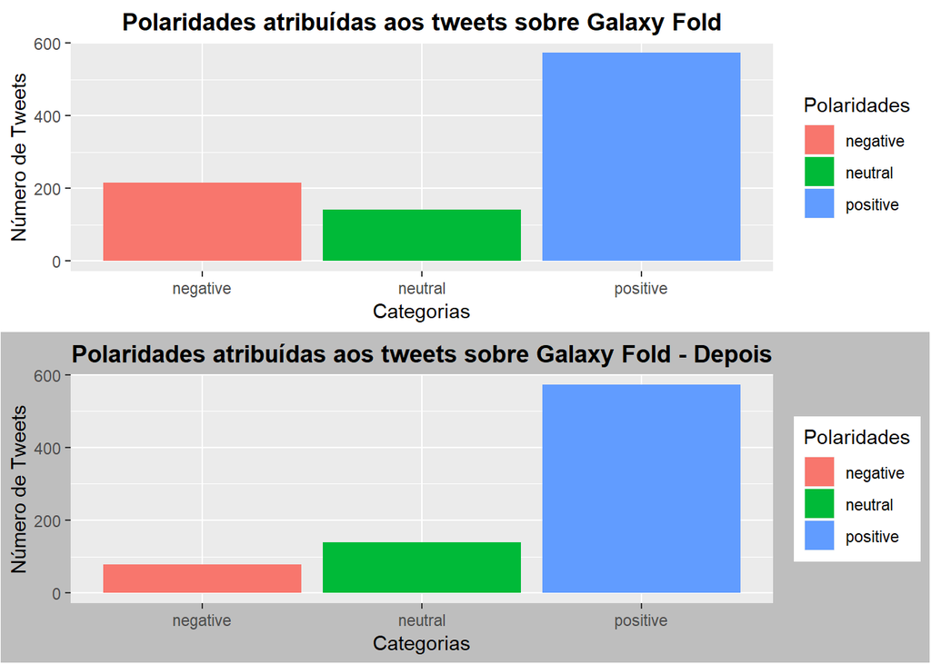

```r
plot_pol_fold_after <- ggplot(resultados_fold_after, aes(x = polaridade)) +
  geom_bar(aes(y = ..count.., fill = polaridade)) +
  scale_fill_brewer(palette = "RdGy") +
  scale_fill_discrete(name = "Polaridades") +
  labs(x = "Categorias", y = "Número de Tweets") +
  ggtitle("Polaridades atribuídas aos tweets sobre Galaxy Fold - Depois") +
  theme(plot.title = element_text(vjust = 0.5, hjust = 0.5, face="bold"),
        plot.background = element_rect(fill = "gray"))

grid.arrange(plot_pol_fold, plot_pol_fold_after, nrow = 2)
```

**Conforme evidenciado houve uma redução da expectativa negativa com a remoção dos tweets com a palavra “dope” e “wild”.**

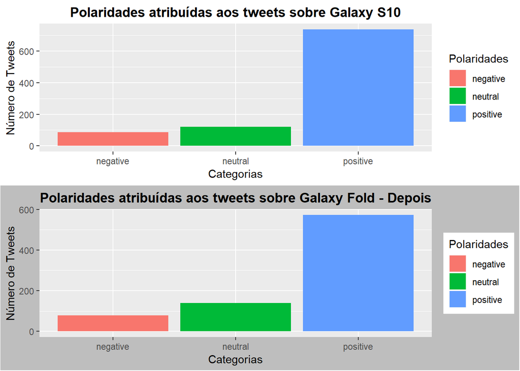

```r
grid.arrange(plot_pol_sten, plot_pol_fold_after, nrow = 2)
```

**Com este avanço a configuração de polaridade ficou com o mesmo padrão obtido para o Galaxy S10, conforme esperado.**

```r
kable(data.frame(table(resultados_fold_after$polaridade)) %>%
  mutate(
    Config = round((Freq / sum(Freq))*100, 2)
  )) %>%
  kable_styling(bootstrap_options = c('striped', 'hover', 'condensed'),
                font_size = 9)
```

| Var1 | Freq | Config |
| --- | --- | --- |
| negative | 79 | 9.97 |
| neutral | 140 | 17.68 |
| positive | 573 | 72.35 |

# Resumo final

# Considerações importantes:

- Este projeto embora simples, demonstra o grande potencial da análise de sentimentos.
- Para uma anáise mais aprimorada deveria haver coleta de diferentes fontes de dados e em diferentes períodos, o que enriqueceria a análise com um conjunto significativamente maior de informações.
- Também seria importante dar foco em palavras positivas para compreender os pontos fortes do produto, podendo assim trabalhar para maior conquista do público.
- Este tipo de análise no contexto de Negócio, é uma abordagem extremamente eficiente para compreender o posicionamento estratégico não só do produto, mas também da empresa, como por exemplo para a composição de uma matriz SWOT.
- A análise de sentimento também pode enriquecer tomadas de ações em diferentes modelos de Negócios, como por exemplo, utilizar de uma abordagem similar para uma pesquisa de satisfação de colaboradores em uma empresa.